# Illumina methylation experiment analysis

Viola Meixian Vuong

*Master Degree in Bioinformatics, University of Bologna*

The following report describes the analytical pipeline of an Illumina Infinium methylation experiment.  
For each of the following steps, codes with their corresponding outputs and, eventually, plots and tables displaying those outputs are also reported.

#### **ANALYSIS PIPELINE**

##### 0 - Preparing the correct environment to perform the analysis, importing all necessary libraries, and loading raw data

Preparing the environment

```r
rm(list = ls()) #Cleaning up the environment
setwd("C:/Users/Dell/Desktop/DRD/Report/Project/") #Setting the working directory
```

Importing all necessary libraries

```r
library(minfi)
library(knitr)
library(kableExtra)
library(IlluminaHumanMethylation450kmanifest)
library(tidyr)
library(graphics)
library(RColorBrewer)
library(gplots)
library(qqman)
```

Loading the raw data

```r
SampleSheet <- read.csv("Input_data_report/Samplesheet_report_2022.csv", header = T)
SampleSheet
```

```
##   Sample Group Sex Age   Sentrix_ID Sentrix_Position
## 1      A    WT   M   1 200400320115           R01C01
## 2      B   MUT   F   1 200400320115           R02C01
## 3      C    WT   M   5 200400320115           R03C01
## 4      D    WT   M   0 200400320115           R04C01
## 5      E   MUT   F   3 200400320115           R02C02
## 6      F   MUT   F   2 200400320115           R03C02
## 7      G    WT   F   9 200400320115           R04C02
## 8      H   MUT   F   1 200400320115           R05C02
```

```r
targets <- read.metharray.sheet("Input_data_report/")
```

```
## [read.metharray.sheet] Found the following CSV files:
```

```
## [1] "Input_data_report/Samplesheet_report_2022.csv"
```

```r
load('C:/Users/Dell/Desktop/DRD/2/Illumina450Manifest_clean.RData')
```

##### 1 - Create an object called RGset storing the RGChannelSet object

```r
RGset <- read.metharray.exp(targets = targets)
RGset
```

```
## class: RGChannelSet
## dim: 622399 8
## metadata(0):
## assays(2): Green Red
## rownames(622399): 10600313 10600322 ... 74810490 74810492
## rowData names(0):
## colnames(8): 200400320115_R01C01 200400320115_R02C01 ...
##   200400320115_R04C02 200400320115_R05C02
## colData names(8): Sample Group ... Basename filenames
## Annotation
##   array: IlluminaHumanMethylation450k
##   annotation: ilmn12.hg19
```

##### 2 - Create the dataframes Red and Green to store the red and green fluorescences, respectively

```r
Red <- data.frame(getRed(RGset))
Green <- data.frame(getGreen(RGset))
```

##### 3 - Fill the following table: what are the Red and Green fluorescences for the address assigned to you? Optional: check in the manifest file if the address corresponds to a Type I or a Type II probe and, in case of Type I probe, report its color.

```r
my_address <- "13673406"
Illumina450Manifest_clean[Illumina450Manifest_clean$AddressA_ID==my_address,]
```

```
##        IlmnID       Name AddressA_ID
## 40 cg01498999 cg01498999    13673406
##                                      AlleleA_ProbeSeq AddressB_ID
## 40 CTTCTAAACAACCCATCAATATTATCAAAAATTTTAAAAAATATAAACCC
##    AlleleB_ProbeSeq Infinium_Design_Type Next_Base Color_Channel
## 40                                    II
##                                                                                                                Forward_Sequence
## 40 GCAAGGCAGTGCTTCTAAACAGCCCATCAGTATTATCAAGAATTTTGAAAAATATGAGCC[CG]GCACTGTGGCTCCTGCCTATCCTCCCAGTACTTTGGGAGGCTGAGGTGTGAGGATTGCTT
##    Genome_Build CHR  MAPINFO                                          SourceSeq
## 40           37   Y 16939383 CGGGCTCATATTTTTCAAAATTCTTGATAATACTGATGGGCTGTTTAGAA
##    Chromosome_36 Coordinate_36 Strand Probe_SNPs Probe_SNPs_10 Random_Loci
## 40             Y      15448777      R                                   NA
##    Methyl27_Loci    UCSC_RefGene_Name        UCSC_RefGene_Accession
## 40            NA NLGN4Y;NLGN4Y;NLGN4Y NR_028318;NM_014893;NR_028319
##    UCSC_RefGene_Group  UCSC_CpG_Islands_Name Relation_to_UCSC_CpG_Island
## 40     Body;Body;Body chrY:16941822-16942188                     N_Shelf
##    Phantom DMR Enhancer HMM_Island Regulatory_Feature_Name
## 40                   NA
##    Regulatory_Feature_Group DHS
## 40                           NA
```

My address - 13673406 - is associated to probe cg01498999, type II.

```r
Illumina450Manifest_clean[Illumina450Manifest_clean$AddressA_ID==my_address,]$Infinium_Design_Type
```

```
## [1] II
## Levels: I II
```

A double-check to see if the result obtained was indeed true was performed. By adding ‘$’, we check the entry in the corresponding column name. Infinium_Design_Type column returns the type of probe we are investigating.

```r
Illumina450Manifest_clean[Illumina450Manifest_clean$AddressA_ID==my_address,]$Color_Channel
```

```
## [1]
## Levels:  Grn Red
```

As our address corresponds to a probe A, type II, the column Color_Channel is indeed empty, as type II probes emit in Green or Red depending on the methylation status of the CpG took under consideration.  
To find out the fluorescences corresponding to our probe, we perform a search in both Red and Green data set built in advance.

```r
Red[rownames(Red)=="13673406",] #Searching for the corresponding R fluorescence(s)
```

```
##          X200400320115_R01C01 X200400320115_R02C01 X200400320115_R03C01
## 13673406                  226                  211                  274
##          X200400320115_R04C01 X200400320115_R02C02 X200400320115_R03C02
## 13673406                  304                  186                  279
##          X200400320115_R04C02 X200400320115_R05C02
## 13673406                  300                  185
```

```r
Green[rownames(Green)=="13673406",] #Searching for the corresponding G fluorescence(s)
```

```
##          X200400320115_R01C01 X200400320115_R02C01 X200400320115_R03C01
## 13673406                 1651                 2445                 2027
##          X200400320115_R04C01 X200400320115_R02C02 X200400320115_R03C02
## 13673406                 1818                  253                  244
##          X200400320115_R04C02 X200400320115_R05C02
## 13673406                 1066                  232
```

A table containing the sample name and its corresponding Red and Green fluorescence is reported down below:

```r
R_fluoro <- t(Red[rownames(Red)==my_address,])
G_fluoro <- t(Green[rownames(Green)==my_address,])
table <- merge(R_fluoro, G_fluoro, by = 0,)
colnames(table) <- c("Sample Name", "Red", "Green")
#Creating the table
kable(head(table), align = "c", caption = "Table 1. Samples fluorescences") %>%
  kable_styling(font_size = 12, html_font = "Times New Roman") %>%
  add_header_above(c(" " = 1, "Fluorescence" = 2))
```

Table 1. Samples fluorescences

| Sample Name | Fluorescence Red | Fluorescence Green |
| --- | --- | --- |
| X200400320115_R01C01 | 226 | 1651 |
| X200400320115_R02C01 | 211 | 2445 |
| X200400320115_R02C02 | 186 | 253 |
| X200400320115_R03C01 | 274 | 2027 |
| X200400320115_R03C02 | 279 | 244 |
| X200400320115_R04C01 | 304 | 1818 |

##### 4 - Create the object MSet.raw

```r
MSet.raw <- preprocessRaw(RGset)
MSet.raw
```

```
## class: MethylSet
## dim: 485512 8
## metadata(0):
## assays(2): Meth Unmeth
## rownames(485512): cg00050873 cg00212031 ... ch.22.47579720R
##   ch.22.48274842R
## rowData names(0):
## colnames(8): 200400320115_R01C01 200400320115_R02C01 ...
##   200400320115_R04C02 200400320115_R05C02
## colData names(8): Sample Group ... Basename filenames
## Annotation
##   array: IlluminaHumanMethylation450k
##   annotation: ilmn12.hg19
## Preprocessing
##   Method: Raw (no normalization or bg correction)
##   minfi version: 1.42.0
##   Manifest version: 0.4.0
```

##### 5 - Perform the following quality checks and provide a brief comment to each step:

##### 5.1 - QCplot

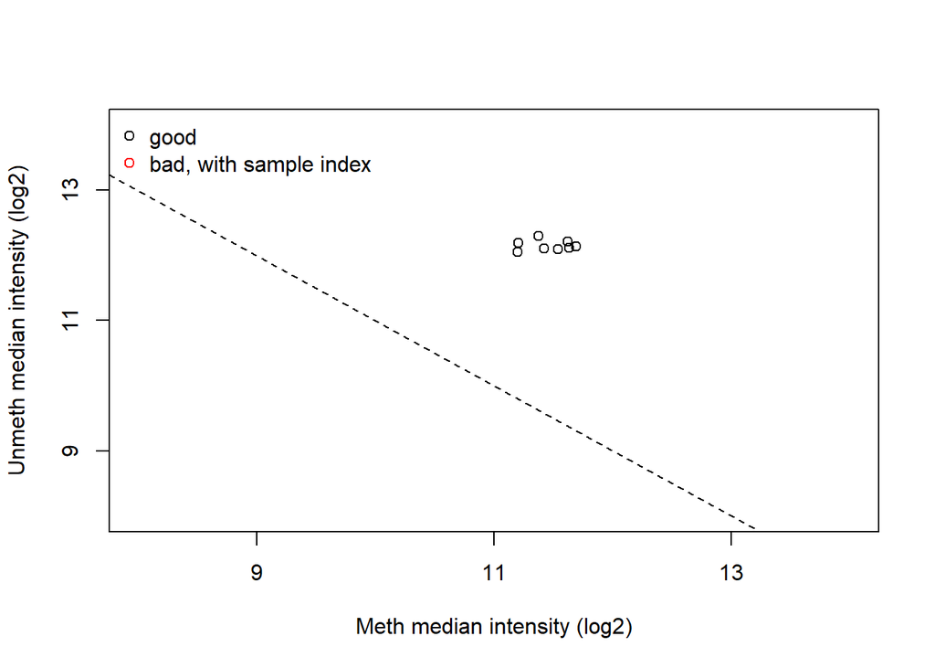

```r
qc <- getQC(MSet.raw)
plotQC(qc)
```

*minfi* provides through the functions *getQC* and *plotQC* a simple quality control plot. The log median intensity of both conditions, methylated (x-axis) and unmethylated (y-axis), are provided; a dash line that cuts across the plot separates the ‘good’ samples from the ‘bad’ ones (it functions as a sort of cut-off). The plot displays the good quality of our samples, as neither one falls in the ‘bad sample’ region. Therefore, all samples have high median intensity.

##### 5.2 - Check the intensity of negative controls using minfi

```r
#Getting info about the control probes and building the corresponding df
df_control <- data.frame(getProbeInfo(RGset, type = "Control"))
#Displaying info about negative controls (just the first 6 entries)
head(df_control[df_control$Type=="NEGATIVE",])
```

```
##     Address     Type  Color ExtendedType
## 49 13792480 NEGATIVE    Red   Negative 1
## 50 69649505 NEGATIVE   Gray   Negative 2
## 51 34772371 NEGATIVE Silver   Negative 3
## 52 28715352 NEGATIVE  Brown   Negative 4
## 53 74737439 NEGATIVE Maroon   Negative 5
## 54 33730459 NEGATIVE   Plum   Negative 6
```

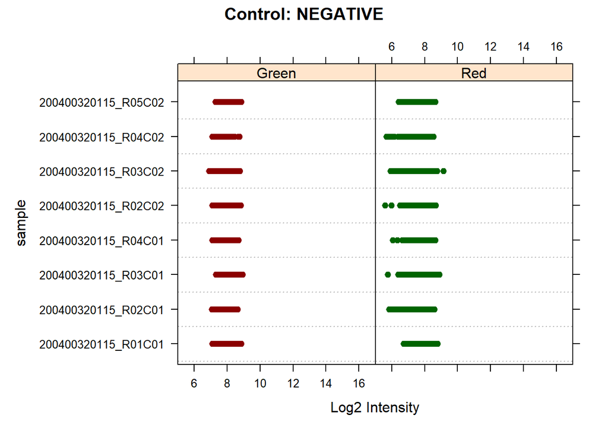

```r
controlStripPlot(RGset, controls = "NEGATIVE")
```

*controlStripPlot* function returns a strip plot of our negative controls. Unfortunately, the color labels are swapped. Nevertheless, we can state here the good quality of the controls. As the background intensity mustn’t be higher than 1000, we can observe that every control lies within 10 (as *log2(1000)=10*) in the *log2* space.

##### 5.3 - Calculate detection pValues; for each sample, how many probes have a detection p-value higher than the threshold assigned to each student?

```r
my_pvalue <- 0.01
detP <- detectionP(RGset)
failed <- detP>my_pvalue
```

To report in tabular form the number of probes passing and failing the threshold value, the failed matrix was first converted into a dataframe. The matrix was manipulated in such way to obtain a dataframe which rows corresponds to the samples, the columns respectively the number of FALSE and TRUE, with FALSE: probes which are *<0.01*; TRUE: probes which are *>0.01*.

```r
failed_df <- t(data.frame(apply(failed, 2, table)))
samples <- rownames(failed_df) #Retrieving the samples names
rownames(failed_df) <- NULL #Removing the first column, corresponding to the index
failed_df <- cbind(samples, failed_df) #Combining the samples by column
colnames(failed_df) <- c("Sample", "< 0.01", "> 0.01")
kable(failed_df, align = "c", caption = "Table 2. Probe detection with respect to the threshold value 0.01") %>%
  kable_styling(font_size = 12, html_font = "Times New Roman") %>%
  add_header_above(c(" " = 1, "p-value" = 2))
```

Table 2. Probe detection with respect to the threshold value 0.01

| Sample | p-value < 0.01 | p-value > 0.01 |
| --- | --- | --- |
| X200400320115_R01C01 | 485456 | 56 |
| X200400320115_R02C01 | 485473 | 39 |
| X200400320115_R03C01 | 485470 | 42 |
| X200400320115_R04C01 | 485477 | 35 |
| X200400320115_R02C02 | 485270 | 242 |
| X200400320115_R03C02 | 485326 | 186 |
| X200400320115_R04C02 | 485491 | 21 |
| X200400320115_R05C02 | 484962 | 550 |

##### 6 - Calculate raw beta and M values and plot the densities of mean methylation values, dividing the samples in WT and MUT (suggestion: subset the beta and M values matrixes in order to retain WT or MUT subjects and apply the function mean to the 2 subsets). Do you see any difference between the two groups?

```r
#Retrieving Beta and M value matrices
beta <- getBeta(MSet.raw)
M <- getM(MSet.raw)
#Dividing the samples by group and retrieving the samples names
sample_df <- SampleSheet %>%
  unite("Sample Name", Sentrix_ID, Sentrix_Position, sep = "_")
mut_samples <- sample_df[sample_df$Group=="MUT", "Sample Name"] #MUT samples name
mut_samples
```

```
## [1] "200400320115_R02C01" "200400320115_R02C02" "200400320115_R03C02"
## [4] "200400320115_R05C02"
```

```r
wt_samples <- sample_df[sample_df$Group=="WT", "Sample Name"] #WT samples name
wt_samples
```

```
## [1] "200400320115_R01C01" "200400320115_R03C01" "200400320115_R04C01"
## [4] "200400320115_R04C02"
```

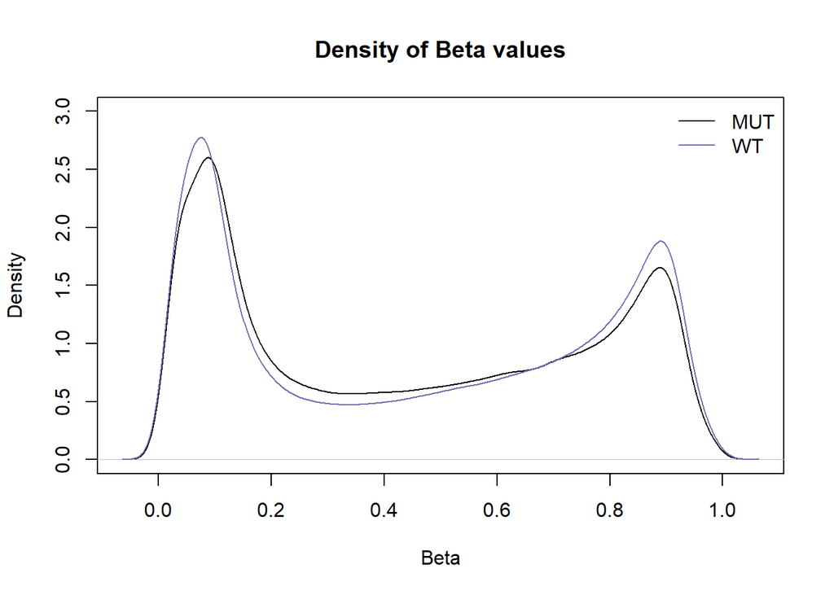

```r
#Beta value subsets
mut_beta <- beta[, sample_df$`Sample Name`%in% mut_samples]
wt_beta <- beta[, sample_df$`Sample Name`%in% wt_samples]
#M value subsets
mut_M <- M[, sample_df$`Sample Name`%in% mut_samples]
wt_M <- M[, sample_df$`Sample Name`%in% wt_samples]
#Means calculation
mut_beta_mean <- apply(mut_beta, 1, mean)
wt_beta_mean <- apply(wt_beta, 1, mean)
mut_M_mean <- apply(mut_M, 1, mean)
wt_M_mean <- apply(wt_M, 1, mean)
#Mean Beta value density plot
{plot(density(mut_beta_mean, na.rm = T), main = "Density of Beta values", col = "black", xlab = "Beta", ylab = "Density", ylim = c(0,3))
  lines(density(wt_beta_mean, na.rm = T), col = "#756bb1")
  legend(legend = c("MUT", "WT"), col = c("black", "#756bb1"), "topright", lty = 1, bty = "n")}
```

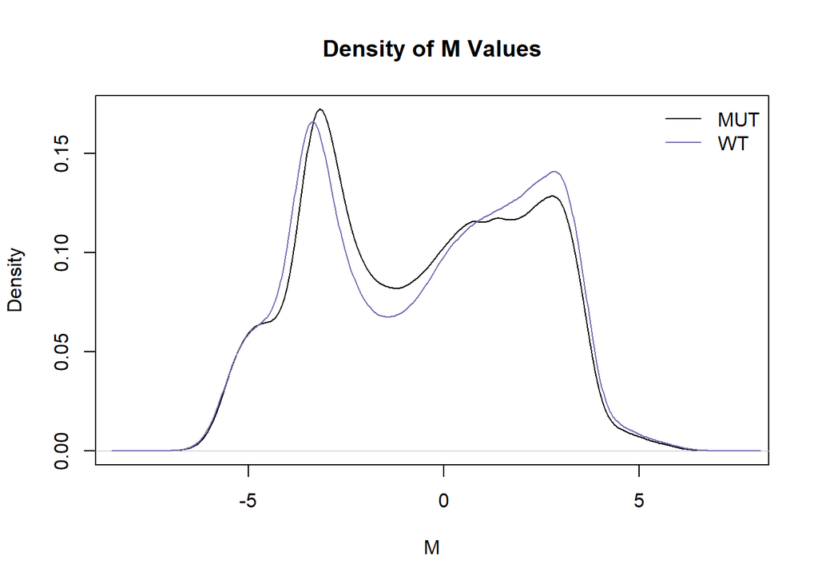

```r
#Mean M value density plot
{plot(density(mut_M_mean, na.rm = T), main = "Density of M Values", col = "black", xlab = "M", ylab = "Density")
  lines(density(wt_M_mean, na.rm = T),col = "#756bb1")
  legend(legend = c("MUT", "WT"), col = c("black", "#756bb1"), "topright", lty = 1, bty = "n")}
```

Looking at both plots we can state that the behavior of the two groups is pretty much the same, even though a slightly difference in terms of density can still be observed. It seems that this behavior is due to the heterogeneity in terms of cell methylation level.

##### 7 - Normalize the data using the function assigned to each student and compare raw data and normalized data. Produce a plot with 6 panels in which, for both raw and normalized data, you show the density plots of beta mean values according to the chemistry of the probes, the density plot of beta standard deviation values according to the chemistry of the probes and the boxplot of beta values. Provide a short comment regarding the changes you observe.

*Function assigned: preprocessQuantile()*

```r
#Subsetting Illumina450Manifest_clean in two dataframes containing only type I and type II probes
inf_I <- Illumina450Manifest_clean[Illumina450Manifest_clean$Infinium_Design_Type=="I",]
inf_I <- droplevels(inf_I)
inf_II <- Illumina450Manifest_clean[Illumina450Manifest_clean$Infinium_Design_Type=="II",]
inf_II <- droplevels(inf_II)
#Subsetting the beta matrix to obtain only rows whose name is in the first column of inf_I and inf_II
beta_I <- beta[rownames(beta) %in% inf_I$IlmnID,]
beta_II <- beta[rownames(beta) %in% inf_II$IlmnID,]
#Calculating the mean and SD of beta values of the previous matrices
beta_I_mean <- apply(beta_I, 1, mean)
beta_II_mean <- apply(beta_II, 1, mean)
beta_I_sd <- apply(beta_I, 1, sd)
beta_II_sd <- apply(beta_II, 1, sd)
#Performing the normalization using the preprocessQuantile function
preprocessQuantile_data <- preprocessQuantile(RGset)
```

```
## [preprocessQuantile] Mapping to genome.
```

```
## [preprocessQuantile] Fixing outliers.
```

```
## [preprocessQuantile] Quantile normalizing.
```

```r
preprocessQuantile_data
```

```
## class: GenomicRatioSet
## dim: 485512 8
## metadata(0):
## assays(2): M CN
## rownames(485512): cg13869341 cg14008030 ... cg08265308 cg14273923
## rowData names(0):
## colnames(8): 200400320115_R01C01 200400320115_R02C01 ...
##   200400320115_R04C02 200400320115_R05C02
## colData names(11): Sample Group ... yMed predictedSex
## Annotation
##   array: IlluminaHumanMethylation450k
##   annotation: ilmn12.hg19
## Preprocessing
##   Method: Raw (no normalization or bg correction)
##   minfi version: 1.42.0
##   Manifest version: 0.4.0
```

```r
#Getting the beta_processQuantile matrix
beta_preprocessQuantile <- getBeta(preprocessQuantile_data)
head(beta_preprocessQuantile)
```

```
##            200400320115_R01C01 200400320115_R02C01 200400320115_R03C01
## cg13869341           0.8435471           0.8152395           0.8468787
## cg14008030           0.7288067           0.5418521           0.7307411
## cg12045430           0.1770831           0.1828376           0.1892301
## cg20826792           0.4109527           0.3904664           0.4072691
## cg00381604           0.1761758           0.1856960           0.1259062
## cg20253340           0.2904163           0.2966039           0.3048458
##            200400320115_R04C01 200400320115_R02C02 200400320115_R03C02
## cg13869341           0.8424558           0.8116403           0.8141401
## cg14008030           0.7194278           0.7064138           0.6862145
## cg12045430           0.2139865           0.2272168           0.2704220
## cg20826792           0.3903241           0.4191039           0.4299213
## cg00381604           0.1738538           0.2602304           0.1562625
## cg20253340           0.3099117           0.3915764           0.3790604
##            200400320115_R04C02 200400320115_R05C02
## cg13869341           0.8365626           0.7705229
## cg14008030           0.6730760           0.5791362
## cg12045430           0.2033585           0.2011479
## cg20826792           0.3573104           0.4434158
## cg00381604           0.1817261           0.2161130
## cg20253340           0.3102283           0.3650535
```

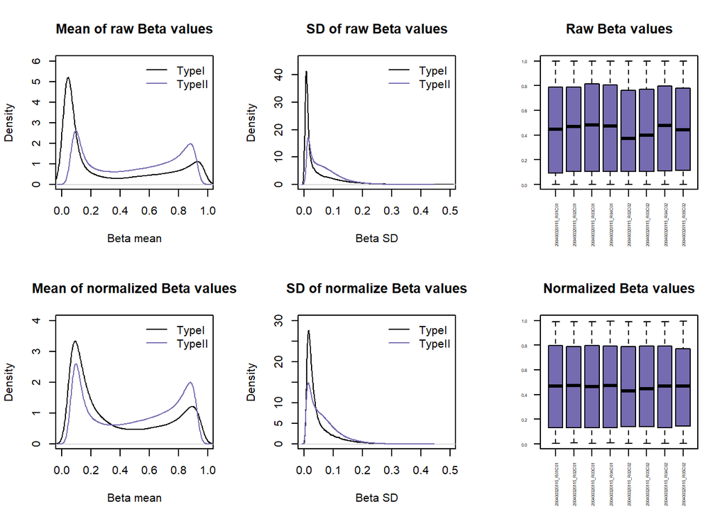

```r
#Dividing the previous matrix according to typeI and typeII probes
beta_preprocessQuantile_I <- beta_preprocessQuantile[rownames(beta_preprocessQuantile) %in% inf_I$IlmnID,]
beta_preprocessQuantile_II <- beta_preprocessQuantile[rownames(beta_preprocessQuantile) %in% inf_II$IlmnID,]
#Computing the mean and SD of the previous matrices
beta_preprocessQuantile_I_mean <- apply(beta_preprocessQuantile_I, 1, mean)
beta_preprocessQuantile_II_mean <- apply(beta_preprocessQuantile_II, 1, mean)
beta_preprocessQuantile_I_sd <- apply(beta_preprocessQuantile_I, 1, sd)
beta_preprocessQuantile_II_sd <- apply(beta_preprocessQuantile_II, 1, sd)
#Plotting
par(mfrow = c(2,3))
{plot(density(beta_I_mean, na.rm = T), col = "black", main = "Mean of raw Beta values", xlim = c(0,1), ylim = c(0,6), xlab = "Beta mean", ylab = "Density")
  lines(density(beta_II_mean, na.rm = T), col = "#756bb1")
  legend(legend = c("TypeI", "TypeII"), col = c("black", "#756bb1"), "topright", lty = 1, bty = "n")}
{plot(density(beta_I_sd, na.rm = T), col = "black", main = "SD of raw Beta values", xlim = c(0,0.5), ylim = c(0,45), xlab = "Beta SD", ylab = "Density")
  lines(density(beta_II_sd, na.rm = T), col = "#756bb1")
  legend(legend = c("TypeI", "TypeII"), col = c("black", "#756bb1"), "topright", lty = 1, bty = "n")}
boxplot(beta, ylim = c(0,1), main = "Raw Beta values", las = 2, col = "#756bb1", cex.axis = 0.4)
{plot(density(beta_preprocessQuantile_I_mean, na.rm = T), col = "black", main = "Mean of normalized Beta values", xlim = c(0,1), ylim = c(0,4), xlab = "Beta mean", ylab = "Density")
  lines(density(beta_preprocessQuantile_II_mean, na.rm = T), col = "#756bb1")
  legend(legend = c("TypeI", "TypeII"), col = c("black", "#756bb1"), "topright", lty = 1:1, bty = "n")}
{plot(density(beta_preprocessQuantile_I_sd, na.rm = T), col = "black", main = "SD of normalize Beta values", xlim = c(0,0.5), ylim = c(0,30), xlab = "Beta SD", ylab = "Density")
  lines(density(beta_preprocessQuantile_II_sd, na.rm = T), col = "#756bb1")
  legend(legend = c("TypeI", "TypeII"), col = c("black", "#756bb1"), "topright", lty = 1:1, bty = "n")}
boxplot(beta_preprocessQuantile, ylim = c(0,1), main = "Normalized Beta values", las = 2, cex.axis = 0.4, col = "#756bb1")
```

1. Mean plots  
“Mean raw beta values” plot tells us that typeII probes are less sensitive than those of typeI, as its range tends to be more “central”. After the normalization procedure, we can see a shift in terms of peaks, which appear to be aligned to typeI ones.  
2. SD plots  
The same can be said for the SD plots. The before-normalization behavior of typeII probes is the same depicted in the raw beta values plot, as the peak is shifted towards the center, referring to the less sensitive capacity of typeII probes to detect extreme methylation values. The normalization procedure aligns the peaks to one another.  
3. BoxPlots  
The normalization procedure of the samples’ beta values lowered significantly the variability. A similar distribution of the beta values across samples can also be observed.

*Optional: do you think that the normalization approach that you used is appropriate considering this specific dataset? Try to color the boxplots according to the group (WT and MUT) and check whether the distribution of methylation values is different between the two groups, before and after normalization …*

```r
SampleSheet$Group
```

```
## [1] "WT"  "MUT" "WT"  "WT"  "MUT" "MUT" "WT"  "MUT"
```

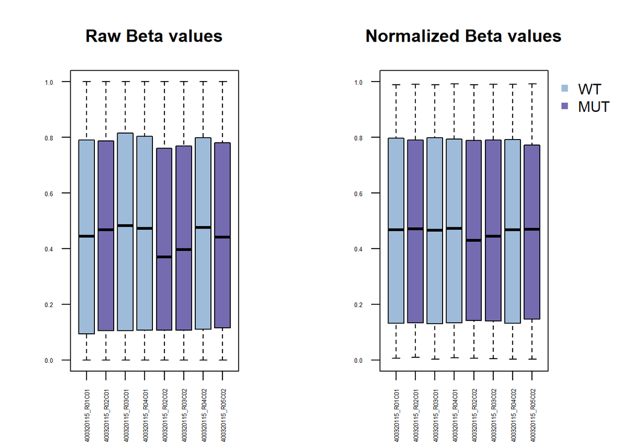

```r
par(mfrow = c(1,2), mar = c(4, 4, 4, 4), xpd = T)
my_col = c("#9ebcda", "#756bb1", "#9ebcda", "#9ebcda", "#756bb1", "#756bb1", "#9ebcda", "#756bb1")
boxplot(beta, ylim = c(0,1), main = "Raw Beta values", las = 2, cex.axis = 0.4, col = my_col)
{boxplot(beta_preprocessQuantile, ylim = c(0,1), main = "Normalized Beta values", las = 2, cex.axis = 0.4, col = my_col)
  coords <- par("usr")
  legend(x = coords[1] * 50, y = coords[4], legend = c("WT", "MUT"), col = my_col, bty = "n", pch = 15)}
```

The normalization procedure adopted here seems to be appropriate especially regarding the WT samples. As we can see in the post-normalization plot, the variability among WT samples is pretty much undetectable. The same can be said also for MUT samples, even though a slightly variability can still be observed.

##### 8 - Perform a PCA on the matrix of normalized beta values generated in step 7, after normalization. Comment the plot (do the samples divide according to the group? Do they divide according to the sex of the samples? Do they divide according to the batch, that is the column Sentrix_ID?).

```r
pca <- prcomp(t(beta_preprocessQuantile), scale = T)
print(summary(pca))
```

```
## Importance of components:
##                            PC1      PC2      PC3      PC4       PC5       PC6
## Standard deviation     396.599 318.8536 280.7100 235.1666 203.88764 164.71119
## Proportion of Variance   0.324   0.2094   0.1623   0.1139   0.08562   0.05588
## Cumulative Proportion    0.324   0.5334   0.6957   0.8096   0.89520   0.95108
##                              PC7       PC8
## Standard deviation     154.11759 2.969e-12
## Proportion of Variance   0.04892 0.000e+00
## Cumulative Proportion    1.00000 1.000e+00
```

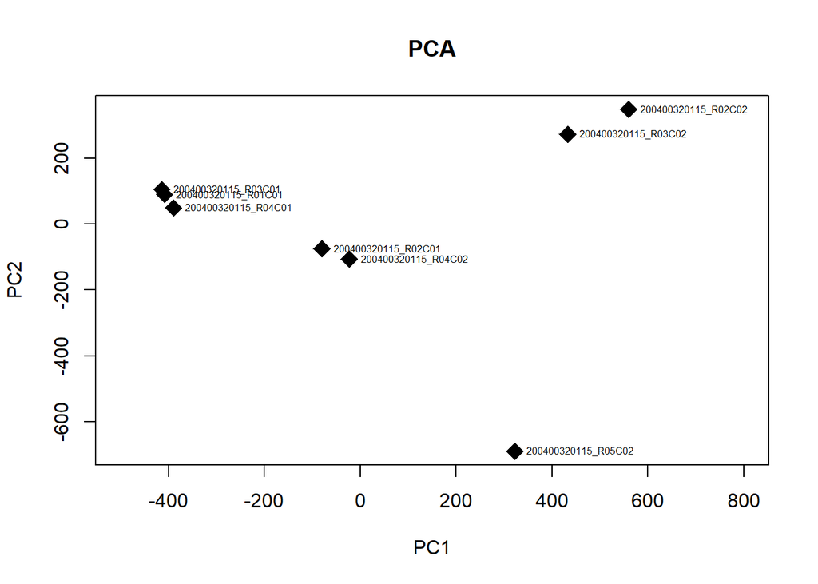

```r
#General plot
{plot(pca$x[, 1], pca$x[, 2], cex = 2, pch = 18, xlab = "PC1", ylab = "PC2", xlim = c(-500, 800), main = "PCA")
  text(pca$x[, 1], pca$x[,2], labels = rownames(pca$x), pos = 4, cex = 0.5)}
```

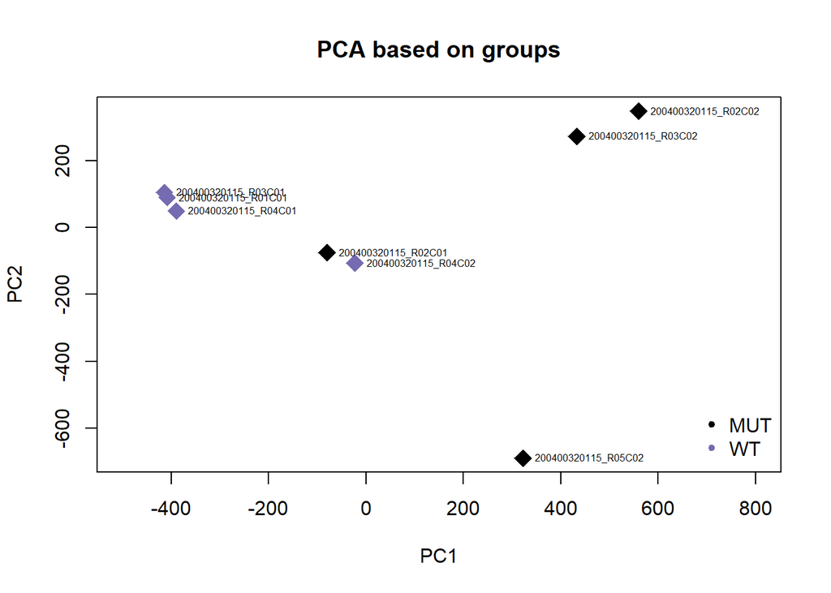

```r
#Group-divided plot
{plot(pca$x[, 1], pca$x[, 2], cex = 2, pch = 18, xlab = "PC1", ylab = "PC2", xlim = c(-500, 800), col = c("black", "#756bb1")[as.factor(SampleSheet$Group)], main = "PCA based on groups")
  text(pca$x[, 1], pca$x[,2], labels = rownames(pca$x), pos = 4, cex = 0.5)
  legend(legend = levels(factor(SampleSheet$Group)), col = c("black", "#756bb1", 1:nlevels(factor(SampleSheet$Group))), pch = 20, "bottomright", bty = "n")}
```

Looking at the PC1, we can infer from the plot how MUT samples have the greatest variability with respect to WT samples. The exceptions are samples R02C01 (MUT sample) and R04C02 (WT sample) which variability along the two components can be define as average (they do not allow us to trace a clean line to separate the samples based on the group they belong to).

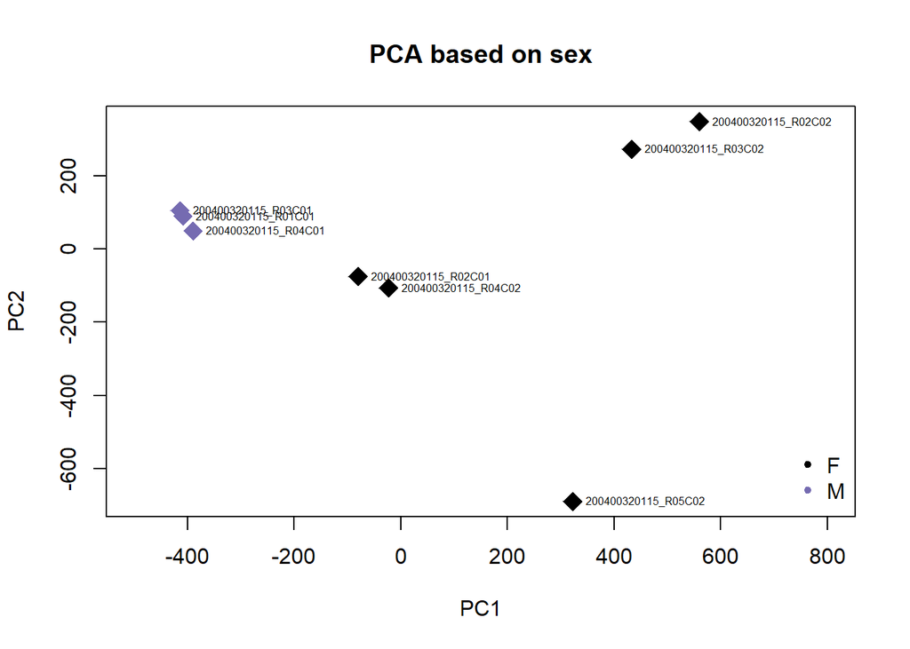

```r
#Sex-divided plot
{plot(pca$x[, 1], pca$x[, 2], cex = 2, pch = 18, xlab = "PC1", ylab = "PC2",xlim = c(-500, 800), col = c("black", "#756bb1")[as.factor(SampleSheet$Sex)], main = "PCA based on sex")
  text(pca$x[, 1], pca$x[,2], labels = rownames(pca$x), pos = 4, cex = 0.5)
  legend(legend = levels(factor(SampleSheet$Sex)), col = c("black", "#756bb1", 1:nlevels(factor(SampleSheet$Sex))), pch = 20, "bottomright", bty = "n")}
```

The plot tells us that we have 5 females and 3 males. A clear division of the samples based on the sex can be observed as females are characterized by the greatest variability (represent by PC1) with respect to males.

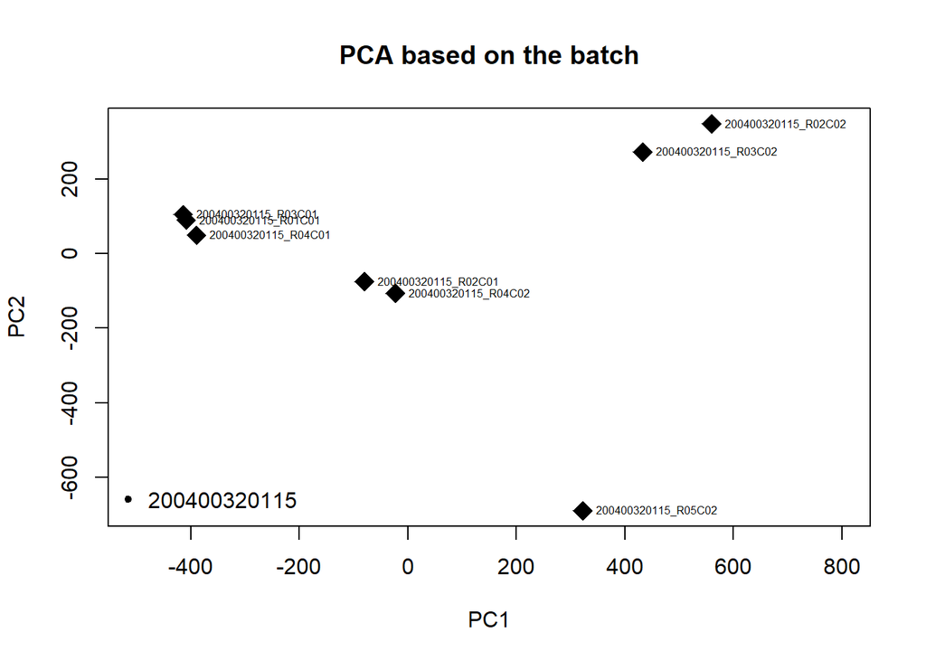

```r
#Sentrix_ID-divided plot
{plot(pca$x[, 1], pca$x[, 2], cex = 2, pch = 18, xlab = "PC1", ylab = "PC2", xlim = c(-500, 800), col = c("black", "#756bb1")[as.factor(SampleSheet$Sentrix_ID)], main = "PCA based on the batch")
  text(pca$x[, 1], pca$x[,2], labels = rownames(pca$x), pos = 4, cex = 0.5)
  legend(legend = levels(factor(SampleSheet$Sentrix_ID)), col = c(1:nlevels(factor(SampleSheet$Sentrix_ID))), pch = 20, "bottomleft", bty = "n")}
```

No samples division is displayed here, all of them belong to the same batch (200400320115).

##### 9 - Using the matrix of normalized beta values generated in step 7, identify differentially methylated probes between group WT and group MUT using the function assigned to each student. Note: it can take several minutes; if you encounter any problem you can run the differential methylation analysis only on a subset of probes (for example those on chromosome 1, 18 and 21)

*Function assigned: t-test*

```r
#Creating an ad hoc function for the t-test
t_test_func <- function(x){
  t_test <- t.test(x ~ SampleSheet$Group)
  return (t_test$p.value)
}
p_value_t_test <- apply(beta_preprocessQuantile, 1, t_test_func)
head(p_value_t_test, n = 20) #Displaying the first 20 entries
```

```
##  cg13869341  cg14008030  cg12045430  cg20826792  cg00381604  cg20253340
## 0.032935519 0.122797564 0.300291519 0.129139261 0.181095791 0.080409006
##  cg21870274  cg03130891  cg24335620  cg16162899  cg17149495  cg22802167
## 0.051184191 0.771751459 0.018826957 0.331875651 0.005200557 0.639464268
##  cg24669183  cg17308840  cg17866181  cg24159721  cg15174812  cg08477687
## 0.290032249 0.302938577 0.041312008 0.238195680 0.107247913 0.045671616
##  cg00034556  cg00645010
## 0.002266952 0.172679376
```

##### 10 - Apply multiple test correction and set a significant threshold of 0.05. How many probes do you identify as differentially methylated considering nominal pValues? How many after Bonferroni correction? How many after BH correction?

```r
#Creating a df with all beta and p_value values
t_test_df <- data.frame(beta_preprocessQuantile, p_value_t_test)
t_test_df <- t_test_df[order(t_test_df$p_value_t_test),]
head(t_test_df)
```

```
##            X200400320115_R01C01 X200400320115_R02C01 X200400320115_R03C01
## cg24988255            0.3436608            0.8686499            0.3480498
## cg00705992            0.3814897            0.8971843            0.3880651
## cg23984976            0.6398142            0.8657880            0.6458484
## cg03637066            0.8395074            0.6443380            0.8402183
## cg13394491            0.1689094            0.3482347            0.1727897
## cg01710147            0.7098313            0.5316241            0.6865911
##            X200400320115_R04C01 X200400320115_R02C02 X200400320115_R03C02
## cg24988255            0.3452074            0.8858763            0.8945762
## cg00705992            0.4162509            0.9300732            0.9144755
## cg23984976            0.6538740            0.8766392            0.8652947
## cg03637066            0.8230702            0.6449962            0.6603760
## cg13394491            0.1562671            0.3344498            0.3404974
## cg01710147            0.6980678            0.5105901            0.5132922
##            X200400320115_R04C02 X200400320115_R05C02 p_value_t_test
## cg24988255            0.3767278            0.9184723   3.653080e-08
## cg00705992            0.4204229            0.8803623   4.305001e-08
## cg23984976            0.6617840            0.8577690   6.188706e-08
## cg03637066            0.8321754            0.6602685   1.088829e-07
## cg13394491            0.1775758            0.3563900   1.863107e-07
## cg01710147            0.7010935            0.5243802   2.101034e-07
```

```r
#Bonferroni correction
p_value_Bon <- p.adjust(t_test_df$p_value_t_test, "bonferroni")
#BH correction
p_value_BH <- p.adjust(t_test_df$p_value_t_test, "BH")
t_test_df_corrected <- data.frame(t_test_df, p_value_Bon, p_value_BH) #Creating a df to display the corrections
head(t_test_df_corrected)
```

```
##            X200400320115_R01C01 X200400320115_R02C01 X200400320115_R03C01
## cg24988255            0.3436608            0.8686499            0.3480498
## cg00705992            0.3814897            0.8971843            0.3880651
## cg23984976            0.6398142            0.8657880            0.6458484
## cg03637066            0.8395074            0.6443380            0.8402183
## cg13394491            0.1689094            0.3482347            0.1727897
## cg01710147            0.7098313            0.5316241            0.6865911
##            X200400320115_R04C01 X200400320115_R02C02 X200400320115_R03C02
## cg24988255            0.3452074            0.8858763            0.8945762
## cg00705992            0.4162509            0.9300732            0.9144755
## cg23984976            0.6538740            0.8766392            0.8652947
## cg03637066            0.8230702            0.6449962            0.6603760
## cg13394491            0.1562671            0.3344498            0.3404974
## cg01710147            0.6980678            0.5105901            0.5132922
##            X200400320115_R04C02 X200400320115_R05C02 p_value_t_test p_value_Bon
## cg24988255            0.3767278            0.9184723   3.653080e-08  0.01773614
## cg00705992            0.4204229            0.8803623   4.305001e-08  0.02090130
## cg23984976            0.6617840            0.8577690   6.188706e-08  0.03004691
## cg03637066            0.8321754            0.6602685   1.088829e-07  0.05286395
## cg13394491            0.1775758            0.3563900   1.863107e-07  0.09045610
## cg01710147            0.7010935            0.5243802   2.101034e-07  0.10200773
##            p_value_BH
## cg24988255 0.01001564
## cg00705992 0.01001564
## cg23984976 0.01001564
## cg03637066 0.01321599
## cg13394491 0.01601301
## cg01710147 0.01601301
```

```r
#Number of probes with p-value less than 0.05
dim(t_test_df_corrected[t_test_df_corrected$p_value_t_test <= 0.05,])
```

```
## [1] 67180    11
```

Probes with p-value less or equal than 0.05 are 67 180.

```r
#Number of probes that has passed the Bonferroni correction
dim(t_test_df_corrected[t_test_df_corrected$p_value_Bon <= 0.05,])
```

```
## [1]  3 11
```

Only 3 probes passed the Bonferroni correction and still have a p-value less or equal than 0.05. As the Bonferroni correction is very stringent, we kind of expect this very low number.

```r
#Number of probes that has passed the BH correction
dim(t_test_df_corrected[t_test_df_corrected$p_value_BH <= 0.05,])
```

```
## [1] 167  11
```

167 probes still have a p-value less or equal than 0.05 following the BH correction.

##### 11 - Produce a volcano plot and a Manhattan plot of the results of differential methylation analysis.

```r
beta_corrected <- t_test_df_corrected[, 1:8]
beta_corrected_wt <- beta_corrected[, factor(SampleSheet$Group)=="WT"] #Beta matrix with p-value corrected of WTs
beta_corrected_mut <- beta_corrected[, factor(SampleSheet$Group)=="MUT"] #Beta matrix with p-value corrected of WTs
mean_beta_corrected_wt <- apply(beta_corrected_wt, 1, mean) #Mean of WTs
mean_beta_corrected_mut <- apply(beta_corrected_mut, 1, mean) #Mean of MUTs
delta <- mean_beta_corrected_wt - mean_beta_corrected_mut #Difference between the avg of both groups
head(delta)
```

```
## cg24988255 cg00705992 cg23984976 cg03637066 cg13394491 cg01710147
## -0.5384822 -0.5039667 -0.2160426  0.1812482 -0.1760075  0.1789243
```

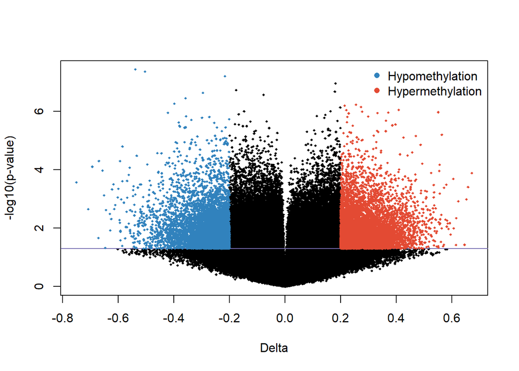

```r
#Creating a df containing the delta values and the -log10 of the p-values
volc_plot <- data.frame(delta, -log10(t_test_df_corrected$p_value_t_test))
#Volcano plot
{plot(volc_plot[, 1], volc_plot[, 2],pch = 18, cex = 0.5, xlab = "Delta", ylab = "-log10(p-value)")
  abline(h = -log10(0.05), b = 0, col = "#756bb1")
hyper_met <- volc_plot[abs(volc_plot[, 1] > 0.2) & volc_plot[, 2] > (-log10(0.05)),]
points(hyper_met[, 1], hyper_met[, 2], pch = 18, cex = 0.5, col = "#e34a33")
hypo_met <- volc_plot[abs(volc_plot[, 1] < (-0.2)) & volc_plot[, 2] > (-log10(0.05)),]
points(hypo_met[, 1], hypo_met[, 2], pch = 18, cex = 0.5, col = "#3182bd")
legend(legend = c("Hypomethylation", "Hypermethylation"), col = c("#3182bd", "#e34a33"), "topright", bty = "n", pch = 16)}
```

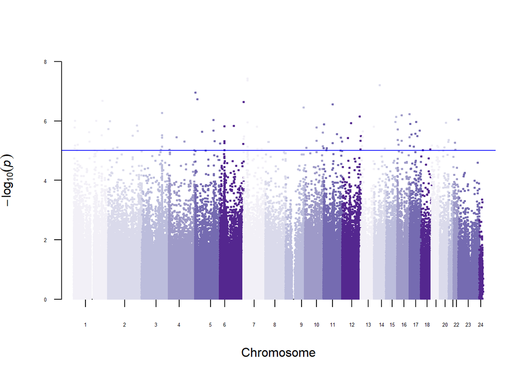

```r
#Converting rows with columns
t_test_df_corrected <- data.frame(rownames(t_test_df_corrected), t_test_df_corrected)
colnames(t_test_df_corrected)[1] <- "IlmnID"
t_test_df_corrected_annotated <- merge(t_test_df_corrected, Illumina450Manifest_clean, by = "IlmnID")
#Manhattan plot
Man_data <- t_test_df_corrected_annotated[colnames(t_test_df_corrected_annotated) %in% c("IlmnID","CHR","MAPINFO","p_value_t_test")]
order_chr <- c("1", "2", "3", "4", "5", "6", "7", "8", "9", "10", "11", "12", "13", "14", "15", "16", "17", "18", "19", "20", "21", "22", "X", "Y")
Man_data$CHR <- as.numeric(factor(Man_data$CHR, levels = order_chr))
manhattan(Man_data, snp = "IlmnID", chr = "CHR", bp = "MAPINFO", p = "p_value_t_test", col = brewer.pal(n = 6, "Purples"), genomewideline = F, cex = 0.5, cex.axis = 0.4)
```

##### 12 - Produce an heatmap of the top 100 differentially methylated probes.

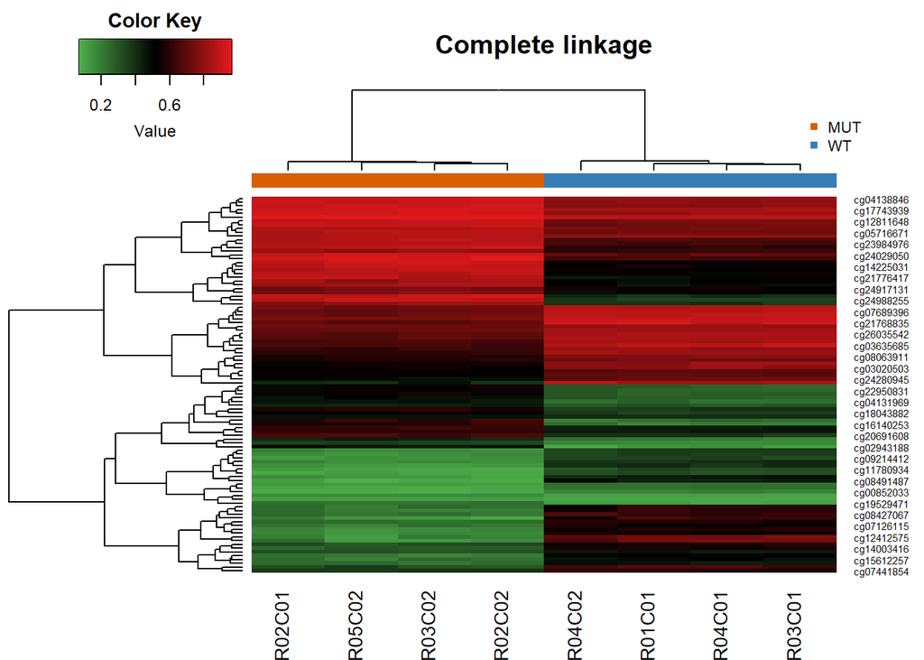

```r
#Creating a matrix containing our input data for the heatmaps
t_test_df_corrected <- data.frame(t_test_df, p_value_Bon, p_value_BH)
heatmap_data = as.matrix(t_test_df_corrected[1:100, 1:8])
#Complete linkage method
colorbar <- c("#377eb8", "#d95f02", "#377eb8", "#377eb8", "#d95f02", "#d95f02", "#377eb8", "#d95f02")
my_col_2 = colorRampPalette(c("#4daf4a", "black", "#e41a1c"))(100)
{heatmap.2(heatmap_data, col = my_col_2, Rowv = T, Colv = T, dendrogram = "both", key = T, ColSideColors = colorbar, density.info = "none", trace = "none", scale = "none", symm = F, main = "Complete linkage")
legend(legend = c("MUT", "WT"), col = c("#d95f02", "#377eb8"), "topright", pch = 15, bty = "n", cex = 0.7)}
```

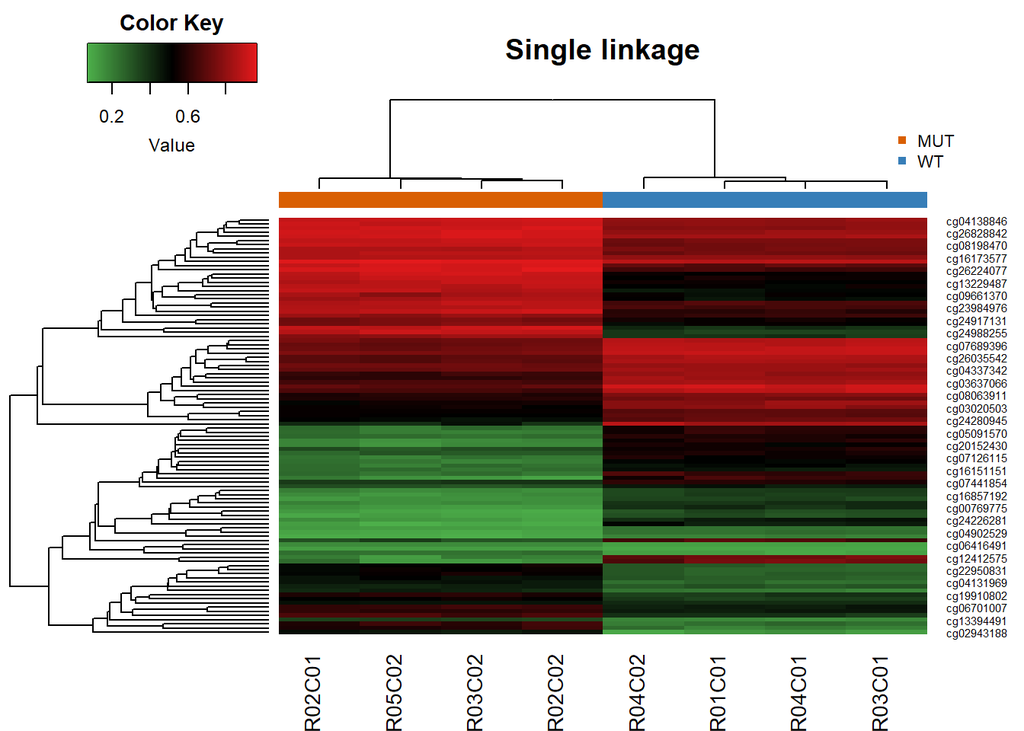

```r
#Single linkage method
{heatmap.2(heatmap_data, col = my_col_2, Rowv = T, Colv = T, hclustfun = function(x) hclust(x, method = 'single'), dendrogram = "both", key = T, ColSideColors = colorbar, density.info = "none", trace = "none", scale = "none", symm = F, main = "Single linkage")
legend(legend = c("MUT", "WT"), col = c("#d95f02", "#377eb8"), "topright", pch = 15, bty = "n", cex = 0.7)}
```

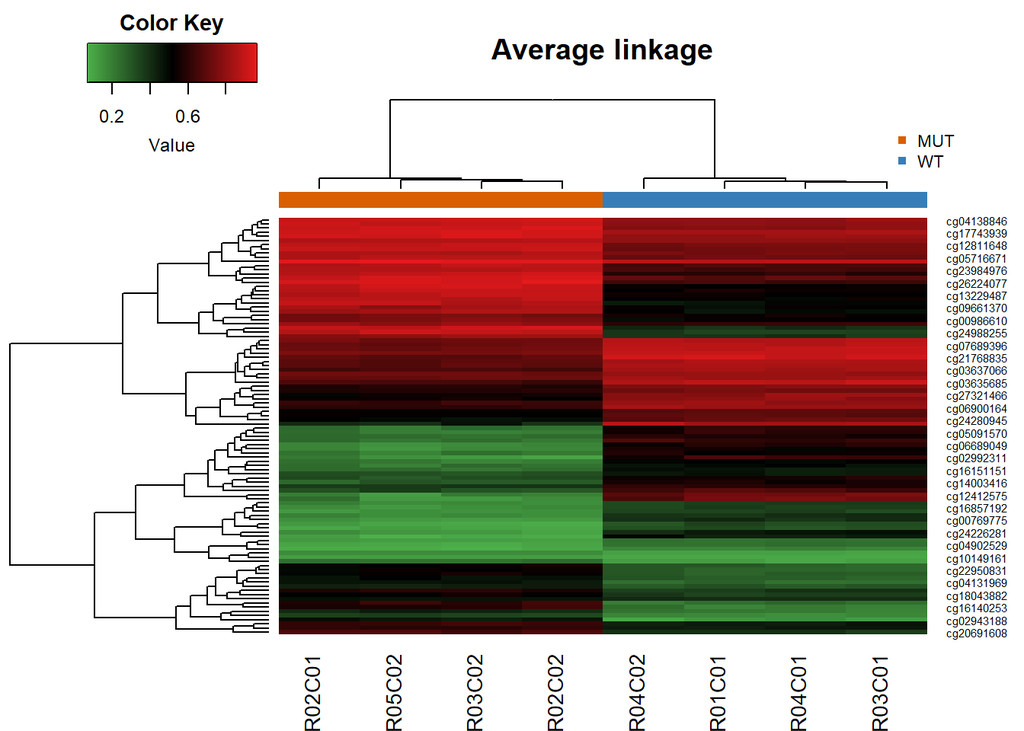

```r
#Average linkage method
{heatmap.2(heatmap_data, col = my_col_2, Rowv = T, Colv = T, hclustfun = function(x) hclust(x, method = 'average'), dendrogram = "both", key = T, ColSideColors = colorbar, density.info = "none", trace = "none", scale = "none", symm = F, main = "Average linkage")
legend(legend = c("MUT", "WT"), col = c("#d95f02", "#377eb8"), "topright", pch = 15, bty = "n", cex = 0.7)}
```